# **The Auralin Phase II clinical trial**

# **Gather**

```python
import pandas as pd
```

```python
patients = pd.read_csv('patients.csv')
treatments = pd.read_csv('treatments.csv')
adverse_reactions = pd.read_csv('adverse_reactions.csv')
```

# **Assess**

In the cells below, each column of each table in this clinical trial dataset is described. To see the table that goes hand in hand with these descriptions, display each table in its entirety by displaying the pandas DataFrame that it was gathered into. This task is the mechanical part of visual assessment in pandas.

```python
# Display the patients table
patients.info()
```

```
<class 'pandas.core.frame.DataFrame'>
RangeIndex: 503 entries, 0 to 502
Data columns (total 14 columns):
 #   Column        Non-Null Count  Dtype
---  ------        --------------  -----
 0   patient_id    503 non-null    int64
 1   assigned_sex  503 non-null    object
 2   given_name    503 non-null    object
 3   surname       503 non-null    object
 4   address       491 non-null    object
 5   city          491 non-null    object
 6   state         491 non-null    object
 7   zip_code      491 non-null    float64
 8   country       491 non-null    object
 9   contact       491 non-null    object
 10  birthdate     503 non-null    object
 11  weight        503 non-null    float64
 12  height        503 non-null    int64
 13  bmi           503 non-null    float64
dtypes: float64(3), int64(2), object(9)
memory usage: 55.1+ KB
```

```python
patients.describe()
```

|  | patient_id | zip_code | weight | height | bmi |
| --- | --- | --- | --- | --- | --- |
| count | 503.000000 | 491.000000 | 503.000000 | 503.000000 | 503.000000 |
| mean | 252.000000 | 49084.118126 | 173.434990 | 66.634195 | 27.483897 |
| std | 145.347859 | 30265.807442 | 33.916741 | 4.411297 | 5.276438 |
| min | 1.000000 | 1002.000000 | 48.800000 | 27.000000 | 17.100000 |
| 25% | 126.500000 | 21920.500000 | 149.300000 | 63.000000 | 23.300000 |
| 50% | 252.000000 | 48057.000000 | 175.300000 | 67.000000 | 27.200000 |
| 75% | 377.500000 | 75679.000000 | 199.500000 | 70.000000 | 31.750000 |
| max | 503.000000 | 99701.000000 | 255.900000 | 79.000000 | 37.700000 |

```python
patients[patients['patient_id'] == 9]
```

|  | patient_id | assigned_sex | given_name | surname | address | city | state | zip_code | country | contact | birthdate | weight | height | bmi |
| --- | --- | --- | --- | --- | --- | --- | --- | --- | --- | --- | --- | --- | --- | --- |
| 8 | 9 | male | Dsvid | Gustafsson | 1790 Nutter Street | Kansas City | MO | 64105.0 | United States | 816-265-9578DavidGustafsson@armyspy.com | 3/6/1937 | 163.9 | 66 | 26.5 |

```python
patients[patients['height'] == 27]
```

|  | patient_id | assigned_sex | given_name | surname | address | city | state | zip_code | country | contact | birthdate | weight | height | bmi |
| --- | --- | --- | --- | --- | --- | --- | --- | --- | --- | --- | --- | --- | --- | --- |
| 4 | 5 | male | Tim | Neudorf | 1428 Turkey Pen Lane | Dothan | AL | 36303.0 | United States | 334-515-7487TimNeudorf@cuvox.de | 2/18/1928 | 192.3 | 27 | 26.1 |

```python
patients[patients['city'] == 'New York']['city'].count()
```

```
18
```

```python
patients[patients['address'].isnull()]
```

|  | patient_id | assigned_sex | given_name | surname | address | city | state | zip_code | country | contact | birthdate | weight | height | bmi |
| --- | --- | --- | --- | --- | --- | --- | --- | --- | --- | --- | --- | --- | --- | --- |
| 209 | 210 | female | Lalita | Eldarkhanov | NaN | NaN | NaN | NaN | NaN | NaN | 8/14/1950 | 143.4 | 62 | 26.2 |
| 219 | 220 | male | Mỹ | Quynh | NaN | NaN | NaN | NaN | NaN | NaN | 4/9/1978 | 237.8 | 69 | 35.1 |
| 230 | 231 | female | Elisabeth | Knudsen | NaN | NaN | NaN | NaN | NaN | NaN | 9/23/1976 | 165.9 | 63 | 29.4 |
| 234 | 235 | female | Martina | Tománková | NaN | NaN | NaN | NaN | NaN | NaN | 4/7/1936 | 199.5 | 65 | 33.2 |
| 242 | 243 | male | John | O'Brian | NaN | NaN | NaN | NaN | NaN | NaN | 2/25/1957 | 205.3 | 74 | 26.4 |
| 249 | 250 | male | Benjamin | Mehler | NaN | NaN | NaN | NaN | NaN | NaN | 10/30/1951 | 146.5 | 69 | 21.6 |
| 257 | 258 | male | Jin | Kung | NaN | NaN | NaN | NaN | NaN | NaN | 5/17/1995 | 231.7 | 69 | 34.2 |
| 264 | 265 | female | Wafiyyah | Asfour | NaN | NaN | NaN | NaN | NaN | NaN | 11/3/1989 | 158.6 | 63 | 28.1 |
| 269 | 270 | female | Flavia | Fiorentino | NaN | NaN | NaN | NaN | NaN | NaN | 10/9/1937 | 175.2 | 61 | 33.1 |
| 278 | 279 | female | Generosa | Cabán | NaN | NaN | NaN | NaN | NaN | NaN | 12/16/1962 | 124.3 | 69 | 18.4 |
| 286 | 287 | male | Lewis | Webb | NaN | NaN | NaN | NaN | NaN | NaN | 4/1/1979 | 155.3 | 68 | 23.6 |
| 296 | 297 | female | Chỉ | Lâm | NaN | NaN | NaN | NaN | NaN | NaN | 5/14/1990 | 181.1 | 63 | 32.1 |

```python
address_counts = patients['address'].value_counts()
address_counts[address_counts>1]
```

```
address
123 Main Street       6
2778 North Avenue     2
2476 Fulton Street    2
648 Old Dear Lane     2
Name: count, dtype: int64
```

```python
patients['surname'].value_counts()
```

```
surname
Doe            6
Jakobsen       3
Taylor         3
Ogochukwu      2
Tucker         2
              ..
Casárez        1
Mata           1
Pospíšil       1
Rukavina       1
Onyekaozulu    1
Name: count, Length: 466, dtype: int64
```

```python
patients[patients['address']=='123 Main Street']
```

|  | patient_id | assigned_sex | given_name | surname | address | city | state | zip_code | country | contact | birthdate | weight | height | bmi |
| --- | --- | --- | --- | --- | --- | --- | --- | --- | --- | --- | --- | --- | --- | --- |
| 215 | 216 | male | John | Doe | 123 Main Street | New York | NY | 12345.0 | United States | johndoe@email.com1234567890 | 1/1/1975 | 180.0 | 72 | 24.4 |
| 229 | 230 | male | John | Doe | 123 Main Street | New York | NY | 12345.0 | United States | johndoe@email.com1234567890 | 1/1/1975 | 180.0 | 72 | 24.4 |
| 237 | 238 | male | John | Doe | 123 Main Street | New York | NY | 12345.0 | United States | johndoe@email.com1234567890 | 1/1/1975 | 180.0 | 72 | 24.4 |
| 244 | 245 | male | John | Doe | 123 Main Street | New York | NY | 12345.0 | United States | johndoe@email.com1234567890 | 1/1/1975 | 180.0 | 72 | 24.4 |
| 251 | 252 | male | John | Doe | 123 Main Street | New York | NY | 12345.0 | United States | johndoe@email.com1234567890 | 1/1/1975 | 180.0 | 72 | 24.4 |
| 277 | 278 | male | John | Doe | 123 Main Street | New York | NY | 12345.0 | United States | johndoe@email.com1234567890 | 1/1/1975 | 180.0 | 72 | 24.4 |

```python
patients[patients['address']=='2778 North Avenue']
```

|  | patient_id | assigned_sex | given_name | surname | address | city | state | zip_code | country | contact | birthdate | weight | height | bmi |
| --- | --- | --- | --- | --- | --- | --- | --- | --- | --- | --- | --- | --- | --- | --- |
| 97 | 98 | male | Patrick | Gersten | 2778 North Avenue | Burr | NE | 68324.0 | United States | PatrickGersten@rhyta.com402-848-4923 | 5/3/1954 | 138.2 | 71 | 19.3 |
| 502 | 503 | male | Pat | Gersten | 2778 North Avenue | Burr | Nebraska | 68324.0 | United States | PatrickGersten@rhyta.com402-848-4923 | 5/3/1954 | 138.2 | 71 | 19.3 |

```python
patients[patients['address']=='2476 Fulton Street']
```

|  | patient_id | assigned_sex | given_name | surname | address | city | state | zip_code | country | contact | birthdate | weight | height | bmi |
| --- | --- | --- | --- | --- | --- | --- | --- | --- | --- | --- | --- | --- | --- | --- |
| 131 | 132 | female | Sandra | Taylor | 2476 Fulton Street | Rainelle | WV | 25962.0 | United States | 304-438-2648SandraCTaylor@dayrep.com | 10/23/1960 | 206.1 | 64 | 35.4 |
| 282 | 283 | female | Sandy | Taylor | 2476 Fulton Street | Rainelle | WV | 25962.0 | United States | 304-438-2648SandraCTaylor@dayrep.com | 10/23/1960 | 206.1 | 64 | 35.4 |

```python
patients[patients['address']=='648 Old Dear Lane']
```

|  | patient_id | assigned_sex | given_name | surname | address | city | state | zip_code | country | contact | birthdate | weight | height | bmi |
| --- | --- | --- | --- | --- | --- | --- | --- | --- | --- | --- | --- | --- | --- | --- |
| 24 | 25 | male | Jakob | Jakobsen | 648 Old Dear Lane | Port Jervis | New York | 12771.0 | United States | JakobCJakobsen@einrot.com+1 (845) 858-7707 | 8/1/1985 | 155.8 | 67 | 24.4 |
| 29 | 30 | male | Jake | Jakobsen | 648 Old Dear Lane | Port Jervis | New York | 12771.0 | United States | JakobCJakobsen@einrot.com+1 (845) 858-7707 | 8/1/1985 | 155.8 | 67 | 24.4 |

```python
patients[patients['address'].duplicated()]
```

|  | patient_id | assigned_sex | given_name | surname | address | city | state | zip_code | country | contact | birthdate | weight | height | bmi |
| --- | --- | --- | --- | --- | --- | --- | --- | --- | --- | --- | --- | --- | --- | --- |
| 29 | 30 | male | Jake | Jakobsen | 648 Old Dear Lane | Port Jervis | New York | 12771.0 | United States | JakobCJakobsen@einrot.com+1 (845) 858-7707 | 8/1/1985 | 155.8 | 67 | 24.4 |
| 219 | 220 | male | Mỹ | Quynh | NaN | NaN | NaN | NaN | NaN | NaN | 4/9/1978 | 237.8 | 69 | 35.1 |
| 229 | 230 | male | John | Doe | 123 Main Street | New York | NY | 12345.0 | United States | johndoe@email.com1234567890 | 1/1/1975 | 180.0 | 72 | 24.4 |
| 230 | 231 | female | Elisabeth | Knudsen | NaN | NaN | NaN | NaN | NaN | NaN | 9/23/1976 | 165.9 | 63 | 29.4 |
| 234 | 235 | female | Martina | Tománková | NaN | NaN | NaN | NaN | NaN | NaN | 4/7/1936 | 199.5 | 65 | 33.2 |
| 237 | 238 | male | John | Doe | 123 Main Street | New York | NY | 12345.0 | United States | johndoe@email.com1234567890 | 1/1/1975 | 180.0 | 72 | 24.4 |
| 242 | 243 | male | John | O'Brian | NaN | NaN | NaN | NaN | NaN | NaN | 2/25/1957 | 205.3 | 74 | 26.4 |
| 244 | 245 | male | John | Doe | 123 Main Street | New York | NY | 12345.0 | United States | johndoe@email.com1234567890 | 1/1/1975 | 180.0 | 72 | 24.4 |
| 249 | 250 | male | Benjamin | Mehler | NaN | NaN | NaN | NaN | NaN | NaN | 10/30/1951 | 146.5 | 69 | 21.6 |
| 251 | 252 | male | John | Doe | 123 Main Street | New York | NY | 12345.0 | United States | johndoe@email.com1234567890 | 1/1/1975 | 180.0 | 72 | 24.4 |
| 257 | 258 | male | Jin | Kung | NaN | NaN | NaN | NaN | NaN | NaN | 5/17/1995 | 231.7 | 69 | 34.2 |
| 264 | 265 | female | Wafiyyah | Asfour | NaN | NaN | NaN | NaN | NaN | NaN | 11/3/1989 | 158.6 | 63 | 28.1 |
| 269 | 270 | female | Flavia | Fiorentino | NaN | NaN | NaN | NaN | NaN | NaN | 10/9/1937 | 175.2 | 61 | 33.1 |
| 277 | 278 | male | John | Doe | 123 Main Street | New York | NY | 12345.0 | United States | johndoe@email.com1234567890 | 1/1/1975 | 180.0 | 72 | 24.4 |
| 278 | 279 | female | Generosa | Cabán | NaN | NaN | NaN | NaN | NaN | NaN | 12/16/1962 | 124.3 | 69 | 18.4 |
| 282 | 283 | female | Sandy | Taylor | 2476 Fulton Street | Rainelle | WV | 25962.0 | United States | 304-438-2648SandraCTaylor@dayrep.com | 10/23/1960 | 206.1 | 64 | 35.4 |
| 286 | 287 | male | Lewis | Webb | NaN | NaN | NaN | NaN | NaN | NaN | 4/1/1979 | 155.3 | 68 | 23.6 |
| 296 | 297 | female | Chỉ | Lâm | NaN | NaN | NaN | NaN | NaN | NaN | 5/14/1990 | 181.1 | 63 | 32.1 |
| 502 | 503 | male | Pat | Gersten | 2778 North Avenue | Burr | Nebraska | 68324.0 | United States | PatrickGersten@rhyta.com402-848-4923 | 5/3/1954 | 138.2 | 71 | 19.3 |

```python
patients[patients['weight']==48.8]
```

|  | patient_id | assigned_sex | given_name | surname | address | city | state | zip_code | country | contact | birthdate | weight | height | bmi |
| --- | --- | --- | --- | --- | --- | --- | --- | --- | --- | --- | --- | --- | --- | --- |
| 210 | 211 | female | Camilla | Zaitseva | 4689 Briarhill Lane | Wooster | OH | 44691.0 | United States | 330-202-2145CamillaZaitseva@superrito.com | 11/26/1938 | 48.8 | 63 | 19.1 |

`patients` columns:

- **patient_id**: the unique identifier for each patient in the [Master Patient Index](https://en.wikipedia.org/wiki/Enterprise_master_patient_index) (i.e. patient database) of the pharmaceutical company that is producing Auralin
- **assigned_sex**: the assigned sex of each patient at birth (male or female)
- **given_name**: the given name (i.e. first name) of each patient
- **surname**: the surname (i.e. last name) of each patient
- **address**: the main address for each patient
- **city**: the corresponding city for the main address of each patient
- **state**: the corresponding state for the main address of each patient
- **zip_code**: the corresponding zip code for the main address of each patient
- **country**: the corresponding country for the main address of each patient (all United states for this clinical trial)
- **contact**: phone number and email information for each patient
- **birthdate**: the date of birth of each patient (month/day/year). The [inclusion criteria](https://en.wikipedia.org/wiki/Inclusion_and_exclusion_criteria) for this clinical trial is age >= 18 *(there is no maximum age because diabetes is a [growing problem](http://www.diabetes.co.uk/diabetes-and-the-elderly.html) among the elderly population)*
- **weight**: the weight of each patient in pounds (lbs)
- **height**: the height of each patient in inches (in)
- **bmi**: the Body Mass Index (BMI) of each patient. BMI is a simple calculation using a person's height and weight. The formula is BMI = kg/m<sup>2</sup> where kg is a person's weight in kilograms and m<sup>2</sup> is their height in metres squared. A BMI of 25.0 or more is overweight, while the healthy range is 18.5 to 24.9. *The [inclusion criteria](https://en.wikipedia.org/wiki/Inclusion_and_exclusion_criteria) for this clinical trial is $16 \leq BMI \leq 38$.*

```python
# Display the treatments table
treatments
```

|  | given_name | surname | auralin | novodra | hba1c_start | hba1c_end | hba1c_change |
| --- | --- | --- | --- | --- | --- | --- | --- |
| 0 | veronika | jindrová | 41u - 48u | - | 7.63 | 7.20 | NaN |
| 1 | elliot | richardson | - | 40u - 45u | 7.56 | 7.09 | 0.97 |
| 2 | yukitaka | takenaka | - | 39u - 36u | 7.68 | 7.25 | NaN |
| 3 | skye | gormanston | 33u - 36u | - | 7.97 | 7.62 | 0.35 |
| 4 | alissa | montez | - | 33u - 29u | 7.78 | 7.46 | 0.32 |
| ... | ... | ... | ... | ... | ... | ... | ... |
| 275 | albina | zetticci | 45u - 51u | - | 7.93 | 7.73 | 0.20 |
| 276 | john | teichelmann | - | 49u - 49u | 7.90 | 7.58 | NaN |
| 277 | mathea | lillebø | 23u - 36u | - | 9.04 | 8.67 | 0.37 |
| 278 | vallie | prince | 31u - 38u | - | 7.64 | 7.28 | 0.36 |
| 279 | samúel | guðbrandsson | 53u - 56u | - | 8.00 | 7.64 | 0.36 |

280 rows × 7 columns

```python
treatments.info()
```

```
<class 'pandas.core.frame.DataFrame'>
RangeIndex: 280 entries, 0 to 279
Data columns (total 7 columns):
 #   Column        Non-Null Count  Dtype
---  ------        --------------  -----
 0   given_name    280 non-null    object
 1   surname       280 non-null    object
 2   auralin       280 non-null    object
 3   novodra       280 non-null    object
 4   hba1c_start   280 non-null    float64
 5   hba1c_end     280 non-null    float64
 6   hba1c_change  171 non-null    float64
dtypes: float64(3), object(4)
memory usage: 15.4+ KB
```

```python
treatments.describe()
```

|  | hba1c_start | hba1c_end | hba1c_change |
| --- | --- | --- | --- |
| count | 280.000000 | 280.000000 | 171.000000 |
| mean | 7.985929 | 7.589286 | 0.546023 |
| std | 0.568638 | 0.569672 | 0.279555 |
| min | 7.500000 | 7.010000 | 0.200000 |
| 25% | 7.660000 | 7.270000 | 0.340000 |
| 50% | 7.800000 | 7.420000 | 0.380000 |
| 75% | 7.970000 | 7.570000 | 0.920000 |
| max | 9.950000 | 9.580000 | 0.990000 |

350 patients participated in this clinical trial. None of the patients were using Novodra (a popular injectable insulin) or Auralin (the oral insulin being researched) as their primary source of insulin before. All were experiencing elevated HbA1c levels.

All 350 patients were treated with Novodra to establish a baseline HbA1c level and insulin dose. After four weeks, which isn’t enough time to capture all the change in HbA1c that can be attributed by the switch to Auralin or Novodra:

- 175 patients switched to Auralin for 24 weeks
- 175 patients continued using Novodra for 24 weeks

`treatments` columns:

- **given_name**: the given name of each patient in the Master Patient Index that took part in the clinical trial
- **surname**: the surname of each patient in the Master Patient Index that took part in the clinical trial
- **auralin**: the baseline median daily dose of insulin from the week prior to switching to Auralin (the number before the dash) *and* the ending median daily dose of insulin at the end of the 24 weeks of treatment measured over the 24th week of treatment (the number after the dash). Both are measured in units (shortform 'u'), which is the [international unit](https://en.wikipedia.org/wiki/International_unit) of measurement and the standard measurement for insulin.
- **novodra**: same as above, except for patients that continued treatment with Novodra
- **hba1c_start**: the patient's HbA1c level at the beginning of the first week of treatment. HbA1c stands for Hemoglobin A1c. The [HbA1c test](https://depts.washington.edu/uwcoe/healthtopics/diabetes.html) measures what the average blood sugar has been over the past three months. It is thus a powerful way to get an overall sense of how well diabetes has been controlled. Everyone with diabetes should have this test 2 to 4 times per year. Measured in %.
- **hba1c_end**: the patient's HbA1c level at the end of the last week of treatment
- **hba1c_change**: the change in the patient's HbA1c level from the start of treatment to the end, i.e., `hba1c_start` - `hba1c_end`. For Auralin to be deemed effective, it must be "noninferior" to Novodra, the current standard for insulin. This "noninferiority" is statistically defined as the upper bound of the 95% confidence interval being less than 0.4% for the difference between the mean HbA1c changes for Novodra and Auralin (i.e. Novodra minus Auralin).

```python
# Display the adverse_reactions table
adverse_reactions
```

|  | given_name | surname | adverse_reaction |
| --- | --- | --- | --- |
| 0 | berta | napolitani | injection site discomfort |
| 1 | lena | baer | hypoglycemia |
| 2 | joseph | day | hypoglycemia |
| 3 | flavia | fiorentino | cough |
| 4 | manouck | wubbels | throat irritation |
| 5 | jasmine | sykes | hypoglycemia |
| 6 | louise | johnson | hypoglycemia |
| 7 | albinca | komavec | hypoglycemia |
| 8 | noe | aranda | hypoglycemia |
| 9 | sofia | hermansen | injection site discomfort |
| 10 | tegan | johnson | headache |
| 11 | abel | yonatan | cough |
| 12 | abdul-nur | isa | hypoglycemia |
| 13 | leon | scholz | injection site discomfort |
| 14 | gabriele | saenger | hypoglycemia |
| 15 | jia li | teng | nausea |
| 16 | jakob | jakobsen | hypoglycemia |
| 17 | christopher | woodward | nausea |
| 18 | ole | petersen | hypoglycemia |
| 19 | finley | chandler | headache |
| 20 | anenechi | chidi | hypoglycemia |
| 21 | miłosław | wiśniewski | injection site discomfort |
| 22 | lixue | hsueh | injection site discomfort |
| 23 | merci | leroux | hypoglycemia |
| 24 | kang | mai | injection site discomfort |
| 25 | elliot | richardson | hypoglycemia |
| 26 | clinton | miller | throat irritation |
| 27 | idalia | moore | hypoglycemia |
| 28 | xiuxiu | chang | hypoglycemia |
| 29 | alex | crawford | hypoglycemia |
| 30 | monika | lončar | hypoglycemia |
| 31 | steven | roy | headache |
| 32 | cecilie | nilsen | hypoglycemia |
| 33 | krisztina | magyar | hypoglycemia |

`adverse_reactions` columns:

- **given_name**: the given name of each patient in the Master Patient Index that took part in the clinical trial and had an adverse reaction (includes both patients treated Auralin and Novodra)
- **surname**: the surname of each patient in the Master Patient Index that took part in the clinical trial and had an adverse reaction (includes both patients treated Auralin and Novodra)
- **adverse_reaction**: the adverse reaction reported by the patient

Additional useful information:

- [Insulin resistance varies person to person](http://www.tudiabetes.org/forum/t/how-much-insulin-is-too-much-on-a-daily-basis/9804/5), which is why both starting median daily dose and ending median daily dose are required, i.e., to calculate change in dose.
- It is important to test drugs and medical products in the people they are meant to help. People of different age, race, sex, and ethnic group must be included in clinical trials. This [diversity](https://www.clinicalleader.com/doc/an-fda-perspective-on-patient-diversity-in-clinical-trials-0001) is reflected in the `patients` table.
- Ensuring column names are descriptive enough is an important step in acquainting yourself with the data. 'Descriptive enough' is subjective. Ideally you want short column names (so they are easier to type and read in code form) but also fully descriptive. Length vs. descriptiveness is a tradeoff and common debate (a [similar debate](https://softwareengineering.stackexchange.com/questions/176582/is-there-an-excuse-for-short-variable-names) exists for variable names). The *auralin* and *novodra* column names are probably not descriptive enough, but you'll address that later so don't worry about that for now.

# **Clean**

## **Assessment Issues**

### Quality Issues

#### `patients` table

- - *zip_code* column is of type float rather a string. $\checkmark$
  - *zip_code* column has four digits sometimes. $\checkmark$
  - Tim Neudorf height is 72 not 27. $\checkmark$
  - Full state names sometimes, abbreviations other times. $\checkmark$
  - The `given_name` for the patient with the `patient_id` 9. $\checkmark$
  - Missing demographic information (address - contact) columns.
  - Erroneous datatypes in (assinged_sex, zip_code, state, birthdate). $\checkmark$
  - Multiple phone number formats > consistency Issue.
  - Default John Doe data.
  - Multiple records for (Jakobsen, Taylor, Gersten)
  - Kgs instead of lbs for Zaitseva.

#### `treatments` table

- - Missing values in `hba1c_change` column. $\checkmark$
  - Letter 'u' in the `auralin` and `novodra` representing the start and end dose. $\checkmark$
  - Lowercase `given_name` and `surname`. $\checkmark$
  - Missing recordes (280 instead of 350). $\checkmark$
  - Erroneous datatypes in (novodra, auralin). $\checkmark$
  - Inaccurate `hba1c_change` of .99. $\checkmark$
  - Nulls represented as (-) in auralin and novodra. $\checkmark$

#### `adverse_reactions` table

- - Lowercase `given_name` and `surname`. $\checkmark$

### Tidiness Issues

#### `patients` table

- - `contact` column should be split into two columns number and email. $\checkmark$

#### `treatments` table

- - Three variables in `novodra`&`auralin` columns should be split into three columns (treatment, start_dose, end_dose) $\checkmark$
  - The table should be referenced by the patient_id instead of given_name and surname. $\checkmark$

#### `adverse_reactions` table

- - This table shouldn't be standalone rather part of the treaments table. $\checkmark$

```python
patients_clean = patients.copy()
treatments_clean = treatments.copy()
adverse_reactions_clean = adverse_reactions.copy()
```

#### `treatments`: Missing recordes (280 instead of 350).

## **Missing Data**

### Code

```python
missing_records = pd.read_csv('treatments_cut.csv')
missing_records
```

|  | given_name | surname | auralin | novodra | hba1c_start | hba1c_end | hba1c_change |
| --- | --- | --- | --- | --- | --- | --- | --- |
| 0 | jožka | resanovič | 22u - 30u | - | 7.56 | 7.22 | 0.34 |
| 1 | inunnguaq | heilmann | 57u - 67u | - | 7.85 | 7.45 | NaN |
| 2 | alwin | svensson | 36u - 39u | - | 7.78 | 7.34 | NaN |
| 3 | thể | lương | - | 61u - 64u | 7.64 | 7.22 | 0.92 |
| 4 | amanda | ribeiro | 36u - 44u | - | 7.85 | 7.47 | 0.38 |
| ... | ... | ... | ... | ... | ... | ... | ... |
| 65 | rovzan | kishiev | 32u - 37u | - | 7.75 | 7.41 | 0.34 |
| 66 | jakob | jakobsen | - | 28u - 26u | 7.96 | 7.51 | 0.95 |
| 67 | bernd | schneider | 48u - 56u | - | 7.74 | 7.44 | 0.30 |
| 68 | berta | napolitani | - | 42u - 44u | 7.68 | 7.21 | NaN |
| 69 | armina | sauvé | 36u - 46u | - | 7.86 | 7.40 | NaN |

70 rows × 7 columns

```python
treatments_clean = pd.concat([treatments_clean, missing_records], ignore_index=True)
```

### Test

```python
treatments_clean.shape
```

```
(350, 7)
```

#### `treatments`: Missing HbA1c changes and Inaccurate HbA1c changes (leading 4s mistaken as 9s)

*Note: the "Inaccurate HbA1c changes (leading 4s mistaken as 9s)" observation, which is an accuracy issue and not a completeness issue, is included in this header because it is also fixed by the cleaning operation that fixes the missing "Missing HbA1c changes" observation. Multiple observations in one* *Define, Code, and Test** header occurs multiple times in this notebook.*

### Define

Calculate the difference between `hba1c_start` and `hba1c_end` and assign it to `hba1c_change`.

### Code

```python
treatments_clean['hba1c_change'] = treatments_clean['hba1c_start'] - treatments_clean['hba1c_end']
```

### Test

```python
treatments_clean['hba1c_change'].info()
```

```
<class 'pandas.core.series.Series'>
RangeIndex: 350 entries, 0 to 349
Series name: hba1c_change
Non-Null Count  Dtype
--------------  -----
350 non-null    float64
dtypes: float64(1)
memory usage: 2.9 KB
```

```python
treatments_clean['hba1c_change'].describe()
```

```
count    350.000000
mean       0.396286
std        0.059283
min        0.200000
25%        0.350000
50%        0.390000
75%        0.440000
max        0.540000
Name: hba1c_change, dtype: float64
```

```python
treatments_clean['hba1c_change'].sample(5)
```

```
94     0.40
51     0.54
278    0.36
103    0.40
7      0.34
Name: hba1c_change, dtype: float64
```

## **Tidiness**

### `patients` Contact column contains two variables: phone number and email

### Define

split the contact column into two columns `phone_number` and `email`

### Code

```python
patients_clean['contact']
```

```
0                 951-719-9170ZoeWellish@superrito.com
1                PamelaSHill@cuvox.de+1 (217) 569-3204
2                     402-363-6804JaeMDebord@gustr.com
3           PhanBaLiem@jourrapide.com+1 (732) 636-8246
4                      334-515-7487TimNeudorf@cuvox.de
                            ...
498        207-477-0579MustafaLindstrom@jourrapide.com
499                 928-284-4492RumanBisliev@gustr.com
500              816-223-6007JinkedeKeizer@teleworm.us
501    ChidaluOnyekaozulu@jourrapide.com1 360 443 2060
502               PatrickGersten@rhyta.com402-848-4923
Name: contact, Length: 503, dtype: object
```

```python
phone_numbers_sample = '''
    951-719-9170
    +1 (217) 569-3204
    1 408 778 3236
'''

emails_sample = '''
    InunnguaqHeilmann@rhyta.com
    YunadiBarsukov@teleworm.us
    ElisabethDimmen@cuvox.de
'''
```

```python
import re
```

```python
phone_number_pattern = re.compile(r'(\+1 |1 )?\(?\d{3}\)?[ .-]\d{3}[ .-]\d{4}')
matches = phone_number_pattern.finditer(phone_numbers_sample)
for match in matches:
    print(match)
```

```
<re.Match object; span=(5, 17), match='951-719-9170'>
<re.Match object; span=(22, 39), match='+1 (217) 569-3204'>
<re.Match object; span=(44, 58), match='1 408 778 3236'>
```

```python
email_pattern = re.compile(r'[a-zA-Z0-9_.-]+@[a-zA-Z0-9.-]+\.[a-zA-Z0-9.-]+')
matches = email_pattern.finditer(emails_sample)
for match in matches:
    print(match)
```

```
<re.Match object; span=(5, 32), match='InunnguaqHeilmann@rhyta.com'>
<re.Match object; span=(37, 63), match='YunadiBarsukov@teleworm.us'>
<re.Match object; span=(68, 92), match='ElisabethDimmen@cuvox.de'>
```

```python
patients_clean['email'] = patients_clean['contact'].str.extract(r'([a-zA-Z_.-]+@[a-zA-Z0-9.-]+\.[a-zA-Z.-]+)')
```

```python
patients_clean['phone_number'] = patients_clean['contact'].str.extract(r'((\+1 |1 )?\(?\d{3}\)?[ .-]\d{3}[ .-]\d{4})')[[0]]
```

```python
patients_clean.pop('contact');
```

### Test

```python
patients_clean['email'].sample(20)
```

```
272     KlementynaSokolowska@superrito.com
458         SousukeNakahara@jourrapide.com
313           MgbankwoAfamefuna@einrot.com
314               RenzoLucchese@dayrep.com
5             RafaelCardosoCosta@gustr.com
428                    MarkoKos@einrot.com
274                  NoraNyborg@einrot.com
143    AmandaCavalcantiRibeiro@fleckens.hu
328                 AnjaHueber@teleworm.us
16                LieuThiThuTam@dayrep.com
63             YukitakaTakenaka@einrot.com
147            KristianVukelic@teleworm.us
177                 MonikaLoncar@rhyta.com
385                  RiceYudina@dayrep.com
381                 RonnieKClapp@gustr.com
365            RobertWagner@jourrapide.com
82          ThachThiKieuChau@superrito.com
488             MikaMartinsson@armyspy.com
359             MerciLeroux@jourrapide.com
360         KermanDandonneau@superrito.com
Name: email, dtype: object
```

```python
patients_clean['phone_number'].sample(20)
```

```
220    +1 (707) 896-9250
273         601-848-3093
296                  NaN
172         319-541-3295
51        1 309 912 9553
417         360-689-4989
144         260-591-5755
451       1 909 982 4264
469         910-264-6229
30          303-910-2058
433         412-449-0733
48          312-719-7238
231       1 252 583 5410
309         256-872-9211
213         917-622-9142
261         617-297-0387
342       1 860 618 4560
363         562-452-5685
471         503-417-1995
47          404-289-1766
Name: phone_number, dtype: object
```

```python
patients_clean
```

|  | patient_id | assigned_sex | given_name | surname | address | city | state | zip_code | country | birthdate | weight | height | bmi | email | phone_number |
| --- | --- | --- | --- | --- | --- | --- | --- | --- | --- | --- | --- | --- | --- | --- | --- |
| 0 | 1 | female | Zoe | Wellish | 576 Brown Bear Drive | Rancho California | California | 92390.0 | United States | 7/10/1976 | 121.7 | 66 | 19.6 | ZoeWellish@superrito.com | 951-719-9170 |
| 1 | 2 | female | Pamela | Hill | 2370 University Hill Road | Armstrong | Illinois | 61812.0 | United States | 4/3/1967 | 118.8 | 66 | 19.2 | PamelaSHill@cuvox.de | +1 (217) 569-3204 |
| 2 | 3 | male | Jae | Debord | 1493 Poling Farm Road | York | Nebraska | 68467.0 | United States | 2/19/1980 | 177.8 | 71 | 24.8 | JaeMDebord@gustr.com | 402-363-6804 |
| 3 | 4 | male | Liêm | Phan | 2335 Webster Street | Woodbridge | NJ | 7095.0 | United States | 7/26/1951 | 220.9 | 70 | 31.7 | PhanBaLiem@jourrapide.com | +1 (732) 636-8246 |
| 4 | 5 | male | Tim | Neudorf | 1428 Turkey Pen Lane | Dothan | AL | 36303.0 | United States | 2/18/1928 | 192.3 | 27 | 26.1 | TimNeudorf@cuvox.de | 334-515-7487 |
| ... | ... | ... | ... | ... | ... | ... | ... | ... | ... | ... | ... | ... | ... | ... | ... |
| 498 | 499 | male | Mustafa | Lindström | 2530 Victoria Court | Milton Mills | ME | 3852.0 | United States | 4/10/1959 | 181.1 | 72 | 24.6 | MustafaLindstrom@jourrapide.com | 207-477-0579 |
| 499 | 500 | male | Ruman | Bisliev | 494 Clarksburg Park Road | Sedona | AZ | 86341.0 | United States | 3/26/1948 | 239.6 | 70 | 34.4 | RumanBisliev@gustr.com | 928-284-4492 |
| 500 | 501 | female | Jinke | de Keizer | 649 Nutter Street | Overland Park | MO | 64110.0 | United States | 1/13/1971 | 171.2 | 67 | 26.8 | JinkedeKeizer@teleworm.us | 816-223-6007 |
| 501 | 502 | female | Chidalu | Onyekaozulu | 3652 Boone Crockett Lane | Seattle | WA | 98109.0 | United States | 2/13/1952 | 176.9 | 67 | 27.7 | ChidaluOnyekaozulu@jourrapide.com | 1 360 443 2060 |
| 502 | 503 | male | Pat | Gersten | 2778 North Avenue | Burr | Nebraska | 68324.0 | United States | 5/3/1954 | 138.2 | 71 | 19.3 | PatrickGersten@rhyta.com | 402-848-4923 |

503 rows × 15 columns

### `treatments` Three variables in two columns (treatment, start dose and end dose)

### Define

Split the `auralin` and `novodra` into three columns `treatment`, `start_dose` and `end_dose`.

### Code

```python
treatments_clean
```

|  | given_name | surname | auralin | novodra | hba1c_start | hba1c_end | hba1c_change |
| --- | --- | --- | --- | --- | --- | --- | --- |
| 0 | veronika | jindrová | 41u - 48u | - | 7.63 | 7.20 | 0.43 |
| 1 | elliot | richardson | - | 40u - 45u | 7.56 | 7.09 | 0.47 |
| 2 | yukitaka | takenaka | - | 39u - 36u | 7.68 | 7.25 | 0.43 |
| 3 | skye | gormanston | 33u - 36u | - | 7.97 | 7.62 | 0.35 |
| 4 | alissa | montez | - | 33u - 29u | 7.78 | 7.46 | 0.32 |
| ... | ... | ... | ... | ... | ... | ... | ... |
| 345 | rovzan | kishiev | 32u - 37u | - | 7.75 | 7.41 | 0.34 |
| 346 | jakob | jakobsen | - | 28u - 26u | 7.96 | 7.51 | 0.45 |
| 347 | bernd | schneider | 48u - 56u | - | 7.74 | 7.44 | 0.30 |
| 348 | berta | napolitani | - | 42u - 44u | 7.68 | 7.21 | 0.47 |
| 349 | armina | sauvé | 36u - 46u | - | 7.86 | 7.40 | 0.46 |

350 rows × 7 columns

```python
treatments_clean = pd.melt(treatments_clean, id_vars=['given_name', 'surname', 'hba1c_start',
                                                      'hba1c_end','hba1c_change'],
                           var_name='treatment', value_name='dose')
```

```python
import numpy as np
treatments_clean['dose'] = treatments_clean['dose'].replace('-', np.nan)
```

```python
treatments_clean.dropna(axis=0, how='any', inplace=True)
```

```python
splitted = treatments_clean['dose'].str.split('-', expand=True)
```

```python
splitted.rename(columns={0:'start_dose', 1:'end_dose'}, inplace=True)
```

```python
splitted['start_dose'] = splitted['start_dose'].str.replace('u', '')
splitted['end_dose'] = splitted['end_dose'].str.replace('u', '')
```

```python
splitted['start_dose'] = splitted['start_dose'].astype(int)
splitted['end_dose'] = splitted['end_dose'].astype(int)
```

```python
treatments_clean = pd.concat([treatments_clean, splitted], axis=1)
```

```python
treatments_clean.pop('dose')
```

```
0      41u - 48u
3      33u - 36u
6      37u - 42u
7      31u - 38u
9      30u - 36u
         ...
688    55u - 51u
690    26u - 23u
694    22u - 23u
696    28u - 26u
698    42u - 44u
Name: dose, Length: 350, dtype: object
```

### Test

```python
treatments_clean
```

|  | given_name | surname | hba1c_start | hba1c_end | hba1c_change | treatment | start_dose | end_dose |
| --- | --- | --- | --- | --- | --- | --- | --- | --- |
| 0 | veronika | jindrová | 7.63 | 7.20 | 0.43 | auralin | 41 | 48 |
| 3 | skye | gormanston | 7.97 | 7.62 | 0.35 | auralin | 33 | 36 |
| 6 | sophia | haugen | 7.65 | 7.27 | 0.38 | auralin | 37 | 42 |
| 7 | eddie | archer | 7.89 | 7.55 | 0.34 | auralin | 31 | 38 |
| 9 | asia | woźniak | 7.76 | 7.37 | 0.39 | auralin | 30 | 36 |
| ... | ... | ... | ... | ... | ... | ... | ... | ... |
| 688 | christopher | woodward | 7.51 | 7.06 | 0.45 | novodra | 55 | 51 |
| 690 | maret | sultygov | 7.67 | 7.30 | 0.37 | novodra | 26 | 23 |
| 694 | lixue | hsueh | 9.21 | 8.80 | 0.41 | novodra | 22 | 23 |
| 696 | jakob | jakobsen | 7.96 | 7.51 | 0.45 | novodra | 28 | 26 |
| 698 | berta | napolitani | 7.68 | 7.21 | 0.47 | novodra | 42 | 44 |

350 rows × 8 columns

### `adverse_reactions` This table shouldn't be standalone rather part of the treaments table.

### Define

Combine `adverse_reactions` and `treatments` tables

### Code

```python
adverse_reactions_clean
```

|  | given_name | surname | adverse_reaction |
| --- | --- | --- | --- |
| 0 | berta | napolitani | injection site discomfort |
| 1 | lena | baer | hypoglycemia |
| 2 | joseph | day | hypoglycemia |
| 3 | flavia | fiorentino | cough |
| 4 | manouck | wubbels | throat irritation |
| 5 | jasmine | sykes | hypoglycemia |
| 6 | louise | johnson | hypoglycemia |
| 7 | albinca | komavec | hypoglycemia |
| 8 | noe | aranda | hypoglycemia |
| 9 | sofia | hermansen | injection site discomfort |
| 10 | tegan | johnson | headache |
| 11 | abel | yonatan | cough |
| 12 | abdul-nur | isa | hypoglycemia |
| 13 | leon | scholz | injection site discomfort |
| 14 | gabriele | saenger | hypoglycemia |
| 15 | jia li | teng | nausea |
| 16 | jakob | jakobsen | hypoglycemia |
| 17 | christopher | woodward | nausea |
| 18 | ole | petersen | hypoglycemia |
| 19 | finley | chandler | headache |
| 20 | anenechi | chidi | hypoglycemia |
| 21 | miłosław | wiśniewski | injection site discomfort |
| 22 | lixue | hsueh | injection site discomfort |
| 23 | merci | leroux | hypoglycemia |
| 24 | kang | mai | injection site discomfort |
| 25 | elliot | richardson | hypoglycemia |
| 26 | clinton | miller | throat irritation |
| 27 | idalia | moore | hypoglycemia |
| 28 | xiuxiu | chang | hypoglycemia |
| 29 | alex | crawford | hypoglycemia |
| 30 | monika | lončar | hypoglycemia |
| 31 | steven | roy | headache |
| 32 | cecilie | nilsen | hypoglycemia |
| 33 | krisztina | magyar | hypoglycemia |

```python
treatments_clean = treatments_clean.merge(adverse_reactions_clean, how='left')
```

### Test

```python
treatments_clean.head(6)
```

|  | given_name | surname | hba1c_start | hba1c_end | hba1c_change | treatment | start_dose | end_dose | adverse_reaction |
| --- | --- | --- | --- | --- | --- | --- | --- | --- | --- |
| 0 | veronika | jindrová | 7.63 | 7.20 | 0.43 | auralin | 41 | 48 | NaN |
| 1 | skye | gormanston | 7.97 | 7.62 | 0.35 | auralin | 33 | 36 | NaN |
| 2 | sophia | haugen | 7.65 | 7.27 | 0.38 | auralin | 37 | 42 | NaN |
| 3 | eddie | archer | 7.89 | 7.55 | 0.34 | auralin | 31 | 38 | NaN |
| 4 | asia | woźniak | 7.76 | 7.37 | 0.39 | auralin | 30 | 36 | NaN |
| 5 | joseph | day | 7.70 | 7.19 | 0.51 | auralin | 29 | 36 | hypoglycemia |

### Define

Isolate the patient ID and names in the patients table, then convert these names to lower case to join with treatments. Then drop the given name and surname columns in the treatments table (so these being lowercase isn't an issue anymore).

### Code

```python
patients_clean['given_name'] = patients_clean['given_name'].str.lower()
patients_clean['surname'] = patients_clean['surname'].str.lower()
id_names = patients_clean[['patient_id', 'given_name', 'surname']]
id_names
```

|  | patient_id | given_name | surname |
| --- | --- | --- | --- |
| 0 | 1 | zoe | wellish |
| 1 | 2 | pamela | hill |
| 2 | 3 | jae | debord |
| 3 | 4 | liêm | phan |
| 4 | 5 | tim | neudorf |
| ... | ... | ... | ... |
| 498 | 499 | mustafa | lindström |
| 499 | 500 | ruman | bisliev |
| 500 | 501 | jinke | de keizer |
| 501 | 502 | chidalu | onyekaozulu |
| 502 | 503 | pat | gersten |

503 rows × 3 columns

```python
treatments_clean = treatments_clean.merge(id_names)
```

```python
treatments_clean.pop('given_name')
treatments_clean.pop('surname')
```

```
0        jindrová
1      gormanston
2          haugen
3          archer
4         woźniak
          ...
344      woodward
345      sultygov
346         hsueh
347      jakobsen
348    napolitani
Name: surname, Length: 349, dtype: object
```

### Test

```python
treatments_clean
```

|  | hba1c_start | hba1c_end | hba1c_change | treatment | start_dose | end_dose | adverse_reaction | patient_id |
| --- | --- | --- | --- | --- | --- | --- | --- | --- |
| 0 | 7.63 | 7.20 | 0.43 | auralin | 41 | 48 | NaN | 225 |
| 1 | 7.97 | 7.62 | 0.35 | auralin | 33 | 36 | NaN | 242 |
| 2 | 7.65 | 7.27 | 0.38 | auralin | 37 | 42 | NaN | 345 |
| 3 | 7.89 | 7.55 | 0.34 | auralin | 31 | 38 | NaN | 276 |
| 4 | 7.76 | 7.37 | 0.39 | auralin | 30 | 36 | NaN | 15 |
| ... | ... | ... | ... | ... | ... | ... | ... | ... |
| 344 | 7.51 | 7.06 | 0.45 | novodra | 55 | 51 | nausea | 153 |
| 345 | 7.67 | 7.30 | 0.37 | novodra | 26 | 23 | NaN | 420 |
| 346 | 9.21 | 8.80 | 0.41 | novodra | 22 | 23 | injection site discomfort | 336 |
| 347 | 7.96 | 7.51 | 0.45 | novodra | 28 | 26 | hypoglycemia | 25 |
| 348 | 7.68 | 7.21 | 0.47 | novodra | 42 | 44 | injection site discomfort | 477 |

349 rows × 8 columns

```python
# Check the patient_id column is the only duplicated one.
all_columns = pd.Series(list(patients_clean)+list(treatments_clean))
all_columns[all_columns.duplicated()]
```

```
22    patient_id
dtype: object
```

## **Quality Issues**

### Zip code is a float not a string and Zip code has four digits sometimes

### Define

Convert to string and pad with zeros for alignment.

### Code

```python
patients_clean['zip_code'] = patients_clean['zip_code'].astype(str).str[:-2].str.pad(5, side='left', fillchar='0')
```

```python
# Reconvert zero entries to nan
import numpy as np
patients_clean['zip_code'] = patients_clean['zip_code'].replace('0000n', np.nan)
```

### Test

```python
patients_clean['zip_code'].sample(5)
```

```
169    19020
312    90017
72     70001
340    93550
452    17111
Name: zip_code, dtype: object
```

## Tim Neudorf height is 72 not 27.

### Define

Assign 72 instead of 27 using .replace method.

### Code

```python
patients_clean[patients_clean['height']==27]
```

|  | patient_id | assigned_sex | given_name | surname | address | city | state | zip_code | country | birthdate | weight | height | bmi | email | phone_number |
| --- | --- | --- | --- | --- | --- | --- | --- | --- | --- | --- | --- | --- | --- | --- | --- |
| 4 | 5 | male | tim | neudorf | 1428 Turkey Pen Lane | Dothan | AL | 36303 | United States | 2/18/1928 | 192.3 | 27 | 26.1 | TimNeudorf@cuvox.de | 334-515-7487 |

```python
patients_clean['height'] = patients_clean['height'].replace(27, 72)
```

### Test

```python
patients_clean[patients_clean['surname']=='neudorf']
```

|  | patient_id | assigned_sex | given_name | surname | address | city | state | zip_code | country | birthdate | weight | height | bmi | email | phone_number |
| --- | --- | --- | --- | --- | --- | --- | --- | --- | --- | --- | --- | --- | --- | --- | --- |
| 4 | 5 | male | tim | neudorf | 1428 Turkey Pen Lane | Dothan | AL | 36303 | United States | 2/18/1928 | 192.3 | 72 | 26.1 | TimNeudorf@cuvox.de | 334-515-7487 |

## Full state names sometimes, abbreviations other times

### Define

Apply a function that converts full state name to state abbreviation for California, New York, Illinois, Florida, and Nebraska.

### Code

```python
state_dict = {'California':'CA',
              'New York'  :'NY',
              'Illinois'  :'IL',
              'Florida'   :'FL',
              'Nebraska'  :'NE'}
for key, val in state_dict.items():
    patients_clean['state'] = patients_clean['state'].str.replace(key, val)
```

### Test

```python
patients_clean['state'].value_counts()
```

```
state
CA    60
NY    47
TX    32
IL    24
FL    22
MA    22
PA    18
GA    15
OH    14
MI    13
OK    13
LA    13
NJ    12
VA    11
WI    10
MS    10
AL     9
TN     9
IN     9
MN     9
NC     8
KY     8
WA     8
MO     7
NE     6
KS     6
ID     6
NV     6
SC     5
IA     5
CT     5
RI     4
ND     4
AR     4
AZ     4
ME     4
CO     4
MD     3
DE     3
SD     3
WV     3
OR     3
VT     2
MT     2
DC     2
AK     1
NM     1
NH     1
WY     1
Name: count, dtype: int64
```

## Dsvid Gustafsson

### Define

Correct the mistyped name

### Code

```python
patients_clean['given_name'] = patients_clean['given_name'].replace('dsvid', 'david')
```

### Test

```python
patients_clean[patients_clean['surname']=='gustafsson']
```

|  | patient_id | assigned_sex | given_name | surname | address | city | state | zip_code | country | birthdate | weight | height | bmi | email | phone_number |
| --- | --- | --- | --- | --- | --- | --- | --- | --- | --- | --- | --- | --- | --- | --- | --- |
| 8 | 9 | male | david | gustafsson | 1790 Nutter Street | Kansas City | MO | 64105 | United States | 3/6/1937 | 163.9 | 66 | 26.5 | DavidGustafsson@armyspy.com | 816-265-9578 |

## Erroneous datatypes (assigned sex, state, zip_code, and birthdate columns)

### Code

```python
# convert assigned_sex into category datatype
patients_clean['assigned_sex'] = patients_clean['assigned_sex'].astype('category')
```

```python
# convert state into category datatype
patients_clean['state'] = patients_clean['state'].astype('category')
```

```python
# convert birthdate to a datetime datatype
patients_clean['birthdate'] = pd.to_datetime(patients_clean['birthdate'])
```

### Test

```python
patients_clean['assigned_sex'].dtype
```

```
CategoricalDtype(categories=['female', 'male'], ordered=False, categories_dtype=object)
```

```python
patients_clean['state'].dtype
```

```
CategoricalDtype(categories=['AK', 'AL', 'AR', 'AZ', 'CA', 'CO', 'CT', 'DC', 'DE', 'FL',
                  'GA', 'IA', 'ID', 'IL', 'IN', 'KS', 'KY', 'LA', 'MA', 'MD',
                  'ME', 'MI', 'MN', 'MO', 'MS', 'MT', 'NC', 'ND', 'NE', 'NH',
                  'NJ', 'NM', 'NV', 'NY', 'OH', 'OK', 'OR', 'PA', 'RI', 'SC',
                  'SD', 'TN', 'TX', 'VA', 'VT', 'WA', 'WI', 'WV', 'WY'],
, ordered=False, categories_dtype=object)
```

```python
patients_clean['birthdate'].dtype
```

```
dtype('<M8[ns]')
```

```python
patients_clean.info()
```

```
<class 'pandas.core.frame.DataFrame'>
RangeIndex: 503 entries, 0 to 502
Data columns (total 15 columns):
 #   Column        Non-Null Count  Dtype
---  ------        --------------  -----
 0   patient_id    503 non-null    int64
 1   assigned_sex  503 non-null    category
 2   given_name    503 non-null    object
 3   surname       503 non-null    object
 4   address       491 non-null    object
 5   city          491 non-null    object
 6   state         491 non-null    category
 7   zip_code      491 non-null    object
 8   country       491 non-null    object
 9   birthdate     503 non-null    datetime64[ns]
 10  weight        503 non-null    float64
 11  height        503 non-null    int64
 12  bmi           503 non-null    float64
 13  email         491 non-null    object
 14  phone_number  485 non-null    object
dtypes: category(2), datetime64[ns](1), float64(2), int64(2), object(8)
memory usage: 53.7+ KB
```

## Multiple phone number formats¶

### Define

Use .str.replace() with regex to uniform the phone numbers format

### Code

```python
phone_numbers_sample = '''
    951-719-9170
    +1 (217) 569-3204
    1 408 778 3236
'''

phone_number_pattern = re.compile(r'(\d )?(\d{3})[ -](\d{3})[ -](\d{4})')
matches = phone_number_pattern.finditer(phone_numbers_sample)
for match in matches:
    print(match.group(1), match.group(2), match.group(3))
```

```
None 951 719
1  408 778
```

```python
sub_nums = phone_number_pattern.sub(r'+1 (\g<2>) \g<3>-\g<4>', phone_numbers_sample)
print(sub_nums)
```

```
    +1 (951) 719-9170
    +1 (217) 569-3204
    +1 (408) 778-3236
```

```python
patients_clean['phone_number'] =patients_clean['phone_number'].str.replace(
                                            r'(\d )?(\d{3})[ -](\d{3})[ -](\d{4})',
                                            r'+1 (\g<2>) \g<3>-\g<4>', regex=True)
```

### Test

```python
patients_clean['phone_number'].sample(10)
```

```
196    +1 (512) 738-2609
155    +1 (618) 261-9896
502    +1 (402) 848-4923
343    +1 (203) 251-3573
409    +1 (716) 897-5050
82     +1 (678) 350-2390
191    +1 (312) 864-5737
348    +1 (608) 527-1021
148    +1 (718) 418-0766
328    +1 (612) 342-6065
Name: phone_number, dtype: object
```

## Default John Doe data

### Define

Remove records with surname 'Doe'

### Code

```python
patients_clean = patients_clean[patients_clean['surname']!='doe']
```

### Test

```python
patients_clean[patients_clean['surname']=='doe']
```

|  | patient_id | assigned_sex | given_name | surname | address | city | state | zip_code | country | birthdate | weight | height | bmi | email | phone_number |
| --- | --- | --- | --- | --- | --- | --- | --- | --- | --- | --- | --- | --- | --- | --- | --- |

## Multiple records for Jakobsen, Gersten, Taylor

### Define

Remove the Jake Jakobsen, Pat Gersten, and Sandy Taylor rows from the `patients` table. These are the nicknames, which happen to also not be in the `treatments` table (removing the wrong name would create a consistency issue between the `patients` and `treatments` table). These are all the second occurrence of the duplicate. These are also the only occurences of non-null duplicate addresses.

### Code

```python
patients_clean = patients_clean[(~patients_clean['address'].duplicated()) & patients_clean['address'].notnull()]
```

### Test

```python
patients_clean
```

|  | patient_id | assigned_sex | given_name | surname | address | city | state | zip_code | country | birthdate | weight | height | bmi | email | phone_number |
| --- | --- | --- | --- | --- | --- | --- | --- | --- | --- | --- | --- | --- | --- | --- | --- |
| 0 | 1 | female | zoe | wellish | 576 Brown Bear Drive | Rancho California | CA | 92390 | United States | 1976-07-10 | 121.7 | 66 | 19.6 | ZoeWellish@superrito.com | +1 (951) 719-9170 |
| 1 | 2 | female | pamela | hill | 2370 University Hill Road | Armstrong | IL | 61812 | United States | 1967-04-03 | 118.8 | 66 | 19.2 | PamelaSHill@cuvox.de | +1 (217) 569-3204 |
| 2 | 3 | male | jae | debord | 1493 Poling Farm Road | York | NE | 68467 | United States | 1980-02-19 | 177.8 | 71 | 24.8 | JaeMDebord@gustr.com | +1 (402) 363-6804 |
| 3 | 4 | male | liêm | phan | 2335 Webster Street | Woodbridge | NJ | 07095 | United States | 1951-07-26 | 220.9 | 70 | 31.7 | PhanBaLiem@jourrapide.com | +1 (732) 636-8246 |
| 4 | 5 | male | tim | neudorf | 1428 Turkey Pen Lane | Dothan | AL | 36303 | United States | 1928-02-18 | 192.3 | 72 | 26.1 | TimNeudorf@cuvox.de | +1 (334) 515-7487 |
| ... | ... | ... | ... | ... | ... | ... | ... | ... | ... | ... | ... | ... | ... | ... | ... |
| 497 | 498 | male | masataka | murakami | 1179 Patton Lane | Tulsa | OK | 74116 | United States | 1937-08-19 | 155.1 | 72 | 21.0 | MasatakaMurakami@einrot.com | +1 (918) 984-9171 |
| 498 | 499 | male | mustafa | lindström | 2530 Victoria Court | Milton Mills | ME | 03852 | United States | 1959-04-10 | 181.1 | 72 | 24.6 | MustafaLindstrom@jourrapide.com | +1 (207) 477-0579 |
| 499 | 500 | male | ruman | bisliev | 494 Clarksburg Park Road | Sedona | AZ | 86341 | United States | 1948-03-26 | 239.6 | 70 | 34.4 | RumanBisliev@gustr.com | +1 (928) 284-4492 |
| 500 | 501 | female | jinke | de keizer | 649 Nutter Street | Overland Park | MO | 64110 | United States | 1971-01-13 | 171.2 | 67 | 26.8 | JinkedeKeizer@teleworm.us | +1 (816) 223-6007 |
| 501 | 502 | female | chidalu | onyekaozulu | 3652 Boone Crockett Lane | Seattle | WA | 98109 | United States | 1952-02-13 | 176.9 | 67 | 27.7 | ChidaluOnyekaozulu@jourrapide.com | +1 (360) 443-2060 |

482 rows × 15 columns

```python
patients_clean[patients_clean['surname'] == 'jakobsen']
```

|  | patient_id | assigned_sex | given_name | surname | address | city | state | zip_code | country | birthdate | weight | height | bmi | email | phone_number |
| --- | --- | --- | --- | --- | --- | --- | --- | --- | --- | --- | --- | --- | --- | --- | --- |
| 24 | 25 | male | jakob | jakobsen | 648 Old Dear Lane | Port Jervis | NY | 12771 | United States | 1985-08-01 | 155.8 | 67 | 24.4 | JakobCJakobsen@einrot.com | +1 (845) 858-7707 |
| 432 | 433 | female | karen | jakobsen | 1690 Fannie Street | Houston | TX | 77020 | United States | 1962-11-25 | 185.2 | 67 | 29.0 | KarenJakobsen@jourrapide.com | +1 (979) 203-0438 |

```python
patients_clean[patients_clean['surname'] == 'gersten']
```

|  | patient_id | assigned_sex | given_name | surname | address | city | state | zip_code | country | birthdate | weight | height | bmi | email | phone_number |
| --- | --- | --- | --- | --- | --- | --- | --- | --- | --- | --- | --- | --- | --- | --- | --- |
| 97 | 98 | male | patrick | gersten | 2778 North Avenue | Burr | NE | 68324 | United States | 1954-05-03 | 138.2 | 71 | 19.3 | PatrickGersten@rhyta.com | +1 (402) 848-4923 |

```python
patients_clean[patients_clean['surname'] == 'taylor']
```

|  | patient_id | assigned_sex | given_name | surname | address | city | state | zip_code | country | birthdate | weight | height | bmi | email | phone_number |
| --- | --- | --- | --- | --- | --- | --- | --- | --- | --- | --- | --- | --- | --- | --- | --- |
| 131 | 132 | female | sandra | taylor | 2476 Fulton Street | Rainelle | WV | 25962 | United States | 1960-10-23 | 206.1 | 64 | 35.4 | SandraCTaylor@dayrep.com | +1 (304) 438-2648 |
| 426 | 427 | male | rogelio | taylor | 4064 Marigold Lane | Miami | FL | 33179 | United States | 1992-09-02 | 186.6 | 69 | 27.6 | RogelioJTaylor@teleworm.us | +1 (305) 434-6299 |

## kgs instead of lbs for Zaitseva weight

### Define

##### Define

Use [advanced indexing](https://stackoverflow.com/a/44913631) to isolate the row where the surname is Zaitseva and convert the entry in its weight field from kg to lbs.

### Code

```python
weight_kg = patients_clean.weight.min()
mask = patients_clean['surname']=='zaitseva'
patients_clean.loc[mask, 'weight'] = weight_kg * 2.20462
```

### Test

```python
patients_clean.loc[mask, 'weight']
```

```
210    107.585456
Name: weight, dtype: float64
```

```python
patients_clean.to_csv('patients_clean.csv', index=False)
treatments_clean.to_csv('treatments_clean.csv', index=False)
```

# **Auralin Vs. Novodra: Clinical Trial Key Metrics**

## **Adverse Reactions**

```python
patients = pd.read_csv('patients_clean.csv')
treatments = pd.read_csv('treatments_clean.csv')
```

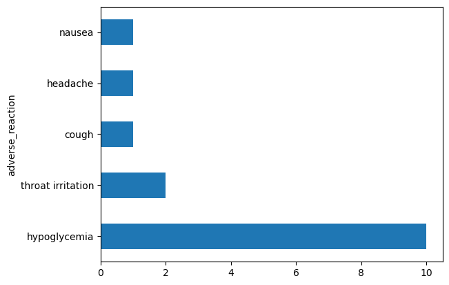

```python
treatments.groupby(['treatment'])['adverse_reaction'].value_counts()['auralin'].plot(kind='barh');
```

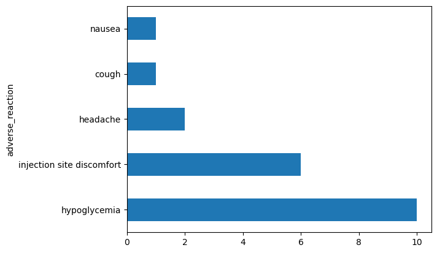

```python
treatments.groupby(['treatment'])['adverse_reaction'].value_counts()['novodra'].plot(kind='barh');
```

## **Pre-trial/Post-trial Mean Insulin Dose Change (UI)**

```python
treatments['dose_change'] = treatments['end_dose'] - treatments['start_dose']
```

```python
treatments.groupby(['treatment'])['dose_change'].mean()
```

```
treatment
auralin    8.325714
novodra   -0.385057
Name: dose_change, dtype: float64
```

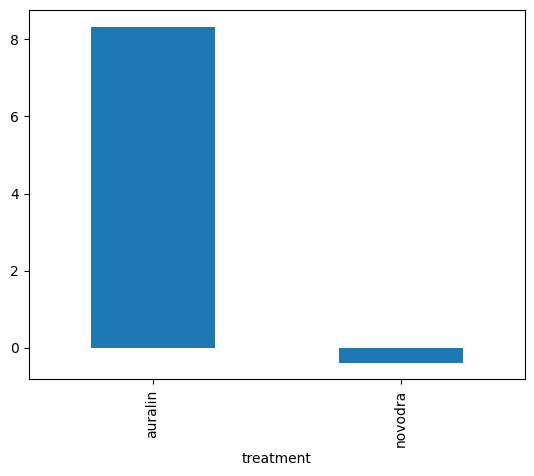

```python
treatments.groupby(['treatment'])['dose_change'].mean().plot(kind='bar')
```

## **Pre-trial/Post-trial Mean HBA1c Change**

```python
treatments.groupby(['treatment'])['hba1c_change'].mean()
```

```
treatment
auralin    0.387657
novodra    0.404713
Name: hba1c_change, dtype: float64
```

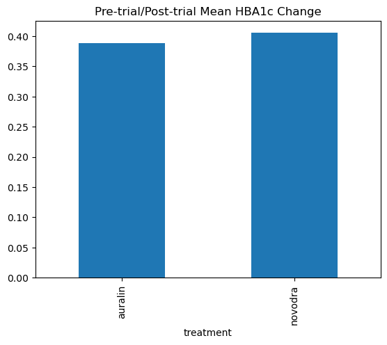

```python
treatments.groupby(['treatment'])['hba1c_change'].mean().plot(kind='bar',
                                                title='Pre-trial/Post-trial Mean HBA1c Change');
```